# Practical Machine Learning - Course Project

Nicolaas Kuit

June 6, 2017

```r
library(caret)
library(doParallel)
library(dplyr)
library(ggplot2)
library(parallel)
library(randomForest)
library(tidyr)
```

# Executive Summary

This report aims to predict how well a person performs a Unilateral Dumbbell Biceps Curl. Data from accelerometers on the belt, forearm, arm, and dumbell of 6 participants is used to classify the bicep curl into one of 5 different movements (*classe* A-E).  
A random forest algorithm is used to classify the movements with an accuracy of around 97%.

```r
set.seed(777)
```

# Data Processing

### Load data

```r
csvTrainingFileName <- "pml-training.csv"
csvTestingFileName <- "pml-testing.csv"

if(!file.exists(csvTrainingFileName)) {
    download.file("https://d396qusza40orc.cloudfront.net/predmachlearn/pml-training.csv", csvTrainingFileName)
}

if(!file.exists(csvTestingFileName)) {
    download.file("https://d396qusza40orc.cloudfront.net/predmachlearn/pml-testing.csv", csvTestingFileName)
}

# The provided training set will be separated into a training and testing set
rawTraining <- read.csv(csvTrainingFileName, stringsAsFactors = FALSE)

# Using the test set as my validation set.
rawValidation <- read.csv(csvTestingFileName, stringsAsFactors = FALSE)
```

### Clean up data

```r
# First we'll remove any columns where there are many NAs
naProps <- apply(is.na(rawTraining), 2, sum) / nrow(rawTraining)

# We see there are two groups of columns. One with zero NAs, and one with more than 90% NAs.
table(naProps)
```

```
## naProps
##                 0 0.979308938946081
##                93                67
```

```r
# Remove all the columns with more than 90% NAs.
naColumnNames <- names(naProps[naProps >= 0.90])

rawTraining <- select(rawTraining, -one_of(naColumnNames))
rawValidation <- select(rawValidation, -one_of(naColumnNames))

# Now look for columns where there are many blank character strings
blankProps <- apply(rawTraining == "", 2, sum) / nrow(rawTraining)
table(blankProps)
```

```
## blankProps
##                 0 0.979308938946081
##                60                33
```

```r
blankColumnNames <- names(blankProps[blankProps >= 0.90])

# Remove all the columns with more than 90% blank character strings.
rawTraining <- select(rawTraining, -one_of(blankColumnNames))
rawValidation <- select(rawValidation, -one_of(blankColumnNames))

# Remove columns related to time. We're just classifying, we're not trying to predict future movements
rawTraining <- select(rawTraining,
                      -X,
                      -raw_timestamp_part_1,
                      -raw_timestamp_part_2,
                      -cvtd_timestamp,
                      -new_window,
                      -num_window)

rawValidation <- select(rawValidation,
                      -X,
                      -raw_timestamp_part_1,
                      -raw_timestamp_part_2,
                      -cvtd_timestamp,
                      -new_window,
                      -num_window)

# Convert the classe (outcome) to a factor
rawTraining$classe <- factor(rawTraining$classe)
rawTraining$user_name <- factor(rawTraining$user_name)

rawValidation$user_name <- factor(rawValidation$user_name)

# Now we're left with a data frame containing only numeric predictors and one outcome (classe).
```

### Create our data partitions

```r
# For our model creation, we need a training, and test set
inTrain <- createDataPartition(rawTraining$classe, p = 0.75, list = FALSE)
training <- rawTraining[inTrain,]
testing <- rawTraining[-inTrain,]
```

### Check for near zero variance in the predictors

We can see below that there are no zero variance predictors.

```r
classeCol <- ncol(training)
nzv <- nearZeroVar(training[,-classeCol], saveMetrics = TRUE)
sum(nzv$zeroVar)
```

```
## [1] 0
```

## Exploratory Analysis

### Plot Histogram of Roll Belt

Plotting the histogram of the variable *roll_belt*, we can clearly see two separate groups (left & right). With such a clear separation, we can use a decision tree model to predict the outcome *classe*.

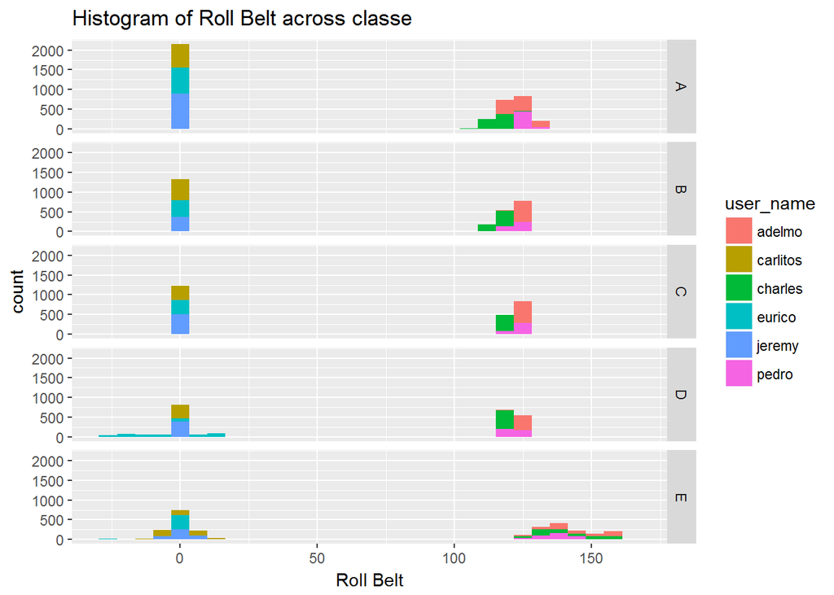

```r
g <- ggplot(data = training, aes(roll_belt, fill = user_name)) +
    facet_grid(classe ~ .) +
    geom_histogram() +
    xlab("Roll Belt") +
    ggtitle("Histogram of Roll Belt across classe")
print(g)
```

## Model Creation

Remove the *user_name* variable since we’d like to apply this model to any new user to be able to tell them whether they are doing the exercise correctly or not.

```r
training <- select(training, -user_name)
validation <- select(rawValidation, -user_name)
```

### Create a smaller training set for Random Forest

```r
# Create a smaller subset as randomForest takes a long time to run.
inSmallTraining <- createDataPartition(training$classe, p = 0.3, list = FALSE)
smallTraining <- training[inSmallTraining,]
smallRemaining <- training[-inSmallTraining,]
```

**Random forest** is used to model the classe outcome. It us usually the best for non-linear classification problems. In order to estimate the test set accuracy, cross validation is performed 5 times. More cross validations could be performed, but it runs very slowly against the random forest algorithm.

```r
cluster <- makeCluster(detectCores() - 1) # convention to leave 1 core for OS
registerDoParallel(cluster)

# Here is where we tell train to cross validate 5 times.
cvControl <- trainControl(method = "cv", number = 5, allowParallel = TRUE)

modrf <- train(classe ~ ., data = smallTraining, method="rf",
              trControl = cvControl,
              prox = TRUE, allowParallel = TRUE)

stopCluster(cluster)
registerDoSEQ()
```

Here we can see that the best set of trees is where 2 variables are picked at random for each decision made in the tree creation process.

```r
modrf
```

```
## Random Forest
##
## 4418 samples
##   52 predictor
##    5 classes: 'A', 'B', 'C', 'D', 'E'
##
## No pre-processing
## Resampling: Cross-Validated (5 fold)
## Summary of sample sizes: 3534, 3535, 3535, 3533, 3535
## Resampling results across tuning parameters:
##
##   mtry  Accuracy   Kappa
##    2    0.9658225  0.9567504
##   27    0.9642375  0.9547428
##   52    0.9579011  0.9467387
##
## Accuracy was used to select the optimal model using  the largest value.
## The final value used for the model was mtry = 2.
```

Below we can see that the out of sample error is 3.1%. We can also see that the model struggles to correctly predict classe *D* with class.error = 0.06.

```r
modrf$finalModel
```

```
##
## Call:
##  randomForest(x = x, y = y, mtry = param$mtry, proximity = TRUE,      allowParallel = TRUE)
##                Type of random forest: classification
##                      Number of trees: 500
## No. of variables tried at each split: 2
##
##         OOB estimate of  error rate: 3.1%
## Confusion matrix:
##      A   B   C   D   E class.error
## A 1246   5   3   2   0 0.007961783
## B   22 817  14   1   1 0.044444444
## C    1  21 742   7   0 0.037613489
## D    1   1  41 678   3 0.063535912
## E    0   3   5   6 798 0.017241379
```

## Performance against test data

Our initial data split into training (75%), validation (25%).  
Training data was then split into:  
- small training (30%)  
- testing (70%)

So our model was built on 75% x 30% = 22.5% of the original data.  
Below our accuracy is 97.34%, which means our error rate is 2.66% (lower than the estimated out of sample error of 3.1%).

```r
confusionMatrix(predict(modrf, smallRemaining), smallRemaining$classe)
```

```
## Confusion Matrix and Statistics
##
##           Reference
## Prediction    A    B    C    D    E
##          A 2910   51    0    2    0
##          B    9 1908   48    0    4
##          C    6   32 1740   79   19
##          D    1    2    8 1606   10
##          E    3    0    0    1 1861
##
## Overall Statistics
##
##                Accuracy : 0.9733
##                  95% CI : (0.97, 0.9763)
##     No Information Rate : 0.2844
##     P-Value [Acc > NIR] : < 2.2e-16
##
##                   Kappa : 0.9662
##  Mcnemar's Test P-Value : < 2.2e-16
##
## Statistics by Class:
##
##                      Class: A Class: B Class: C Class: D Class: E
## Sensitivity            0.9935   0.9574   0.9688   0.9514   0.9826
## Specificity            0.9928   0.9927   0.9840   0.9976   0.9995
## Pos Pred Value         0.9821   0.9690   0.9275   0.9871   0.9979
## Neg Pred Value         0.9974   0.9898   0.9934   0.9905   0.9961
## Prevalence             0.2844   0.1935   0.1744   0.1639   0.1839
## Detection Rate         0.2825   0.1852   0.1689   0.1559   0.1807
## Detection Prevalence   0.2877   0.1912   0.1821   0.1580   0.1811
## Balanced Accuracy      0.9932   0.9750   0.9764   0.9745   0.9911
```

## Performance against validation data

Below our accuracy is 97.33%, which means our error rate is 2.67% (lower than the estimated out of sample error of 3.1%).

It is surprizing that the out of sample error rate is below our estimated OOB error rate.

```r
confusionMatrix(predict(modrf, testing), testing$classe)
```

```
## Confusion Matrix and Statistics
##
##           Reference
## Prediction    A    B    C    D    E
##          A 1389   27    0    2    0
##          B    0  905   21    0    3
##          C    5   14  830   35    9
##          D    1    3    4  767    7
##          E    0    0    0    0  882
##
## Overall Statistics
##
##                Accuracy : 0.9733
##                  95% CI : (0.9684, 0.9776)
##     No Information Rate : 0.2845
##     P-Value [Acc > NIR] : < 2.2e-16
##
##                   Kappa : 0.9662
##  Mcnemar's Test P-Value : NA
##
## Statistics by Class:
##
##                      Class: A Class: B Class: C Class: D Class: E
## Sensitivity            0.9957   0.9536   0.9708   0.9540   0.9789
## Specificity            0.9917   0.9939   0.9844   0.9963   1.0000
## Pos Pred Value         0.9795   0.9742   0.9295   0.9808   1.0000
## Neg Pred Value         0.9983   0.9889   0.9938   0.9910   0.9953
## Prevalence             0.2845   0.1935   0.1743   0.1639   0.1837
## Detection Rate         0.2832   0.1845   0.1692   0.1564   0.1799
## Detection Prevalence   0.2892   0.1894   0.1821   0.1595   0.1799
## Balanced Accuracy      0.9937   0.9738   0.9776   0.9752   0.9895
```

# Conclusion

The random forest algorithm is very accurate in classifying how well someone performed a bicep curl with a dumbell.